# Assignment 12

Ganesh Kodi

November 20, 2018

### Warm Up: Brief Financial Data

#### Summary

EuStockMarkets is sample data sets of prominent stocks over time avaialale natively in R. Extract DAX index data from European stock data (EuStockMarkets) and analyse the DAX data. Firstly, checking whether the data is Additive or Mulitplicative data and later, decide whether transformation required or not

```r
#Display EuStockMarkets dataset
summary(EuStockMarkets)
```

```
##       DAX            SMI            CAC            FTSE
##  Min.   :1402   Min.   :1587   Min.   :1611   Min.   :2281
##  1st Qu.:1744   1st Qu.:2166   1st Qu.:1875   1st Qu.:2843
##  Median :2141   Median :2796   Median :1992   Median :3247
##  Mean   :2531   Mean   :3376   Mean   :2228   Mean   :3566
##  3rd Qu.:2722   3rd Qu.:3812   3rd Qu.:2274   3rd Qu.:3994
##  Max.   :6186   Max.   :8412   Max.   :4388   Max.   :6179
```

```r
#Extract DAX timeseries dataset from EuStockMarkets
dax <- EuStockMarkets[,1]
summary(dax) # Summary of the DAX index
```

```
##    Min. 1st Qu.  Median    Mean 3rd Qu.    Max.
##    1402    1744    2141    2531    2722    6186
```

##### Inference:

Based on summary statistics, maximum vs minimum value are not huge ratio i.e. more than 10, Transformation is not necessary. Model is of Additive type. Continue with original DAX data would be prefered for analysis.

#### Plot

Rudimentary plot for European stock data and DAX stock data

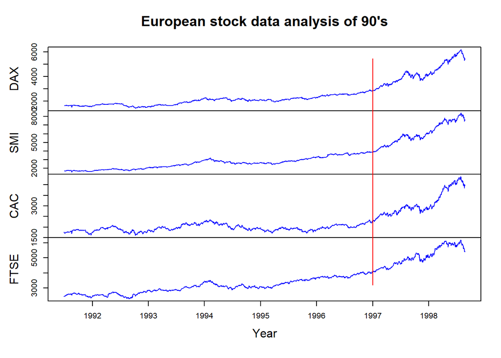

```r
# Plot the line graph of the European Stock Markets Data
plot(EuStockMarkets, col="blue", xlab="Year", ylab="Index value", main="European stock data analysis of 90's" )
abline(v=1997, col="red")
```

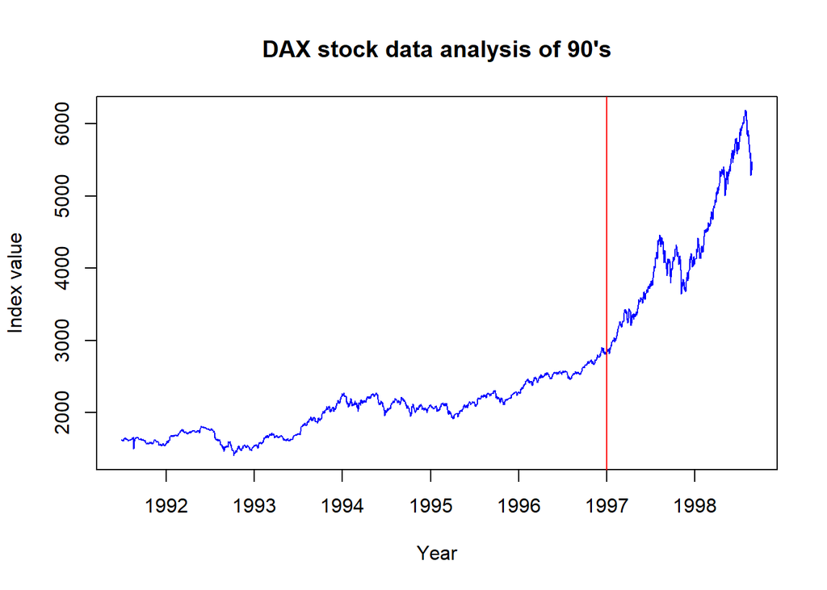

```r
# Plot the line graph of the DAX Stock Markets Data
plot(dax, col="blue", xlab="Year", ylab="Index value", main="DAX stock data analysis of 90's" )
abline(v=1997, col="red")
```